# Analysis of Movie Budgets and Revenues

Loris Diotallevi

2025-02-13

# Introduction

This report presents a comprehensive analysis of the relationship between movie budgets and gross revenues.  
The dataset includes various movies along with their financial and categorical details.  
The objective of this analysis is to identify the best statistical model that accurately predicts the gross revenue based on the movie’s budget.

# Libraries

```r
suppressPackageStartupMessages({
  library(dplyr)
  library(mgcv)
  library(splines)
  library(caret)
  library(ggplot2)
})

library(conflicted)
conflict_prefer("filter", "dplyr")
```

```
## [conflicted] Will prefer dplyr::filter over any other package.
```

```r
conflict_prefer("select", "dplyr")
```

```
## [conflicted] Will prefer dplyr::select over any other package.
```

# Data Loading and Cleaning

This section describes how the data was loaded and cleaned to prepare for analysis.

```r
# Uploading the data
movies <- read.csv("C:/Users/andre/Downloads/movies.csv", stringsAsFactors = FALSE, fileEncoding = "ISO-8859-1")

# Handling missing values
is_invalid_rating <- function(rating) {
  rating <- tolower(trimws(rating))  # Removes unnecessary spaces
  grepl("unrated|not rated|not specified", rating) | rating == ""
}
movies$rating <- ifelse(is_invalid_rating(movies$rating), NA, movies$rating)

# Handling numeric values (Replaces 0 with NA)
numeric_fields <- c("budget", "gross", "runtime", "score", "votes", "year")
movies[numeric_fields] <- lapply(movies[numeric_fields], function(x) replace(x, x == 0 | is.na(x), NA))

# Handling text values (Replaces 'unknown', 'none', 'n/a', and empty strings with NA)
text_fields <- c("company", "country", "director", "genre", "name", "released", "star", "writer")
invalid_text_values <- c("", "unknown", "none", "n/a")
movies[text_fields] <- lapply(movies[text_fields], function(x) ifelse(tolower(trimws(x)) %in% invalid_text_values, NA, x))

# Removing missing values
movies_clean <- na.omit(movies)

# Calculating the percentage of missing data
original_missing_data_percentage <- mean(is.na(movies)) * 100
clean_missing_data_percentage <- mean(is.na(movies_clean)) * 100

# Calculating the range of values for 'gross'
gross_range_value <- diff(range(movies_clean$gross, na.rm = TRUE))

# Printing the results
cat("Original missing data percentage:", round(original_missing_data_percentage, 2), "%\n")
```

```
## Original missing data percentage: 2.44 %
```

```r
cat("Missing data percentage after cleaning:", round(clean_missing_data_percentage, 2), "%\n")
```

```
## Missing data percentage after cleaning: 0 %
```

```r
cat("Range of values for 'gross':", gross_range_value, "\n")
```

```
## Range of values for 'gross': 936661916
```

# Statistical Analysis

## Simple Linear Regression

We begin our analysis of the relationship between **gross** and **budget** by first applying a **simple linear regression**.  
This method assumes a linear relationship between the two variables and is commonly used as an initial approach to understand how **budget** impacts **gross revenue** (which is the natural response variable).

A simple linear regression provides a **direct measure** of a movie’s financial success influenced by its budget.

```r
simple_lm <- lm(gross ~ budget, data = movies_clean)
summary(simple_lm)
```

```
##
## Call:
## lm(formula = gross ~ budget, data = movies_clean)
##
## Residuals:
##        Min         1Q     Median         3Q        Max
## -213861614  -20549880   -7543127   10996176  655350888
##
## Coefficients:
##              Estimate Std. Error t value Pr(>|t|)
## (Intercept) 5.521e+06  9.792e+05   5.638 1.82e-08 ***
## budget      1.126e+00  1.805e-02  62.362  < 2e-16 ***
## ---
## Signif. codes:  0 '***' 0.001 '**' 0.01 '*' 0.05 '.' 0.1 ' ' 1
##
## Residual standard error: 48920000 on 4573 degrees of freedom
## Multiple R-squared:  0.4596, Adjusted R-squared:  0.4595
## F-statistic:  3889 on 1 and 4573 DF,  p-value: < 2.2e-16
```

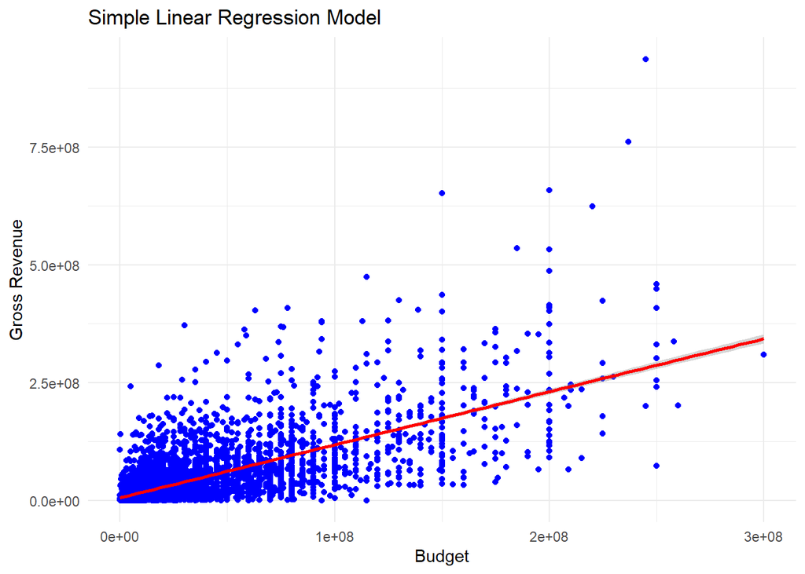

```r
# Plot the simple linear regression
ggplot(movies_clean, aes(x = budget, y = gross)) +
  geom_point(color = "blue", shape = 16) +  # Scatter plot of the data points
  geom_smooth(method = "lm", formula = y ~ x, color = "red") +  # Add the regression line
  labs(title = "Simple Linear Regression Model",
       x = "Budget",
       y = "Gross Revenue") +
  theme_minimal()
```

## Polynomial Regression

Polynomial regression is utilized to capture more complex, non-linear patterns that simple linear regression might miss.  
This method allows us to model the relationship between **budget** and **gross revenue** in a more flexible way by incorporating polynomial terms.

```r
set.seed(1)  # Ensure reproducibility

# Ensure that train_data is defined
if (!exists("train_data")) {
  train_data <- movies_clean[, c("gross", "budget"), drop = FALSE]
  train_data <- subset(train_data, budget > 0)  # Remove movies with a budget of 0
}

# Explicitly define columns to avoid issues
train_data <- train_data %>%
  dplyr::rename(gross = gross, budget = budget) %>%
  dplyr::mutate(
    gross = as.numeric(gross),
    budget = as.numeric(budget)
  )

# Debugging: Print statements to check if data exists
cat("✅ Does train_data exist? ", exists("train_data"), "\n")
```

```
## ✅ Does train_data exist?  TRUE
```

```r
cat("✅ Structure of train_data:\n")
```

```
## ✅ Structure of train_data:
```

```r
print(str(train_data))
```

```
## 'data.frame':    4575 obs. of  2 variables:
##  $ gross : num  5.23e+07 7.01e+07 1.80e+08 8.52e+07 1.86e+07 ...
##  $ budget: num  8000000 6000000 15000000 18500000 9000000 6000000 25000000 6000000 9000000 15000000 ...
## NULL
```

```r
cat("✅ First rows of train_data:\n")
```

```
## ✅ First rows of train_data:
```

```r
print(head(train_data))
```

```
##       gross   budget
## 1  52287414  8000000
## 2  70136369  6000000
## 3 179800601 15000000
## 4  85160248 18500000
## 5  18564613  9000000
## 6 138530565  6000000
```

```r
# Check if the columns are numeric
cat("✅ Column classes: ", sapply(train_data, class), "\n")
```

```
## ✅ Column classes:  numeric numeric
```

```r
# Verify if there are NA values
cat("✅ Are there any NA values in gross? ", any(is.na(train_data$gross)), "\n")
```

```
## ✅ Are there any NA values in gross?  FALSE
```

```r
cat("✅ Are there any NA values in budget? ", any(is.na(train_data$budget)), "\n")
```

```
## ✅ Are there any NA values in budget?  FALSE
```

```r
# Define the polynomial degrees to be tested
degrees <- 1:4

# Perform cross-validation for each polynomial degree
cv_results <- lapply(degrees, function(degree) {
  cat("\n🔍 Testing polynomial degree:", degree, "\n")  # Debugging

  # Manually construct polynomial columns
  train_data_fixed <- train_data
  for (d in 2:degree) {
    train_data_fixed[[paste0("budget_poly_", d)]] <- train_data_fixed$budget^d
  }

  # Dynamically construct the formula
  formula_poly <- as.formula(
    paste("gross ~", paste(c("budget", paste0("budget_poly_", 2:degree)), collapse = " + "))
  )

  cat("📝 Formula used in the model:", format(formula_poly), "\n")  # Debug: Print the constructed formula

  # Train the model
  model <- train(
    formula_poly,
    data = train_data_fixed,
    method = "lm",
    trControl = trainControl(method = "cv", number = 10, savePredictions = "final")
  )

  # Retrieve the minimum RMSE
  if (!is.null(model$results)) {
    rmse_value <- min(model$results$RMSE, na.rm = TRUE)
  } else {
    rmse_value <- NA  # If `model$results` is NULL, assign NA
  }

  list(Model = model, RMSE = rmse_value)
})
```

```
##
## 🔍 Testing polynomial degree: 1
## 📝 Formula used in the model: gross ~ budget + budget_poly_2 + budget_poly_1
```

```
##
## 🔍 Testing polynomial degree: 2
## 📝 Formula used in the model: gross ~ budget + budget_poly_2
##
## 🔍 Testing polynomial degree: 3
## 📝 Formula used in the model: gross ~ budget + budget_poly_2 + budget_poly_3
##
## 🔍 Testing polynomial degree: 4
## 📝 Formula used in the model: gross ~ budget + budget_poly_2 + budget_poly_3 + budget_poly_4
```

```r
# Identify the polynomial degree with the lowest RMSE
best_degree <- degrees[which.min(sapply(cv_results, function(x) x$RMSE))]

# Final refit with the best degree
final_poly_model <- lm(formula = gross ~ poly(budget, best_degree, raw = TRUE), data = train_data)

# Print the summary of the final model
summary(final_poly_model)
```

```
##
## Call:
## lm(formula = gross ~ poly(budget, best_degree, raw = TRUE), data = train_data)
##
## Residuals:
##        Min         1Q     Median         3Q        Max
## -253684332  -20169925   -9917381   10826317  618195840
##
## Coefficients:
##                                         Estimate Std. Error t value Pr(>|t|)
## (Intercept)                            1.036e+07  1.250e+06   8.289  < 2e-16
## poly(budget, best_degree, raw = TRUE)1 8.639e-01  4.595e-02  18.801  < 2e-16
## poly(budget, best_degree, raw = TRUE)2 1.607e-09  2.596e-10   6.189 6.59e-10
##
## (Intercept)                            ***
## poly(budget, best_degree, raw = TRUE)1 ***
## poly(budget, best_degree, raw = TRUE)2 ***
## ---
## Signif. codes:  0 '***' 0.001 '**' 0.01 '*' 0.05 '.' 0.1 ' ' 1
##
## Residual standard error: 48720000 on 4572 degrees of freedom
## Multiple R-squared:  0.4641, Adjusted R-squared:  0.4638
## F-statistic:  1980 on 2 and 4572 DF,  p-value: < 2.2e-16
```

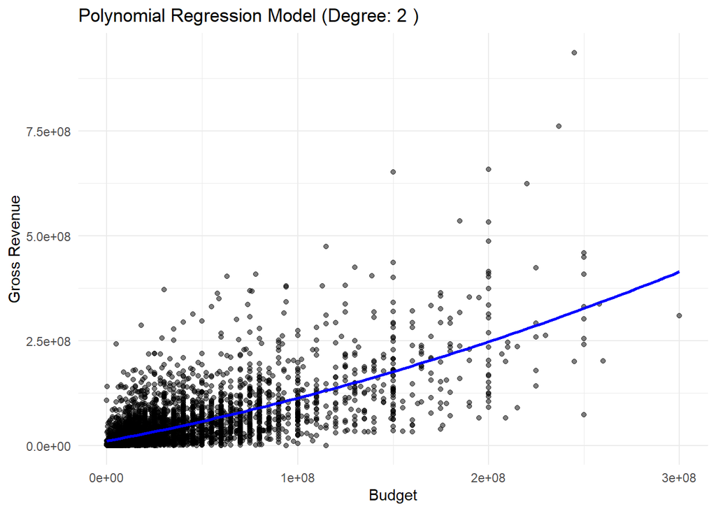

```r
# Plot the polynomial regression model
ggplot(train_data, aes(x = budget, y = gross)) +
  geom_point(alpha = 0.5) +  # Scatter plot with transparency
  geom_smooth(method = "lm",
              formula = as.formula(paste("y ~ poly(x,", best_degree, ", raw = TRUE)")),
              se = FALSE,
              color = "blue") +  # Polynomial regression curve
  labs(title = paste("Polynomial Regression Model (Degree:", best_degree, ")"),
       x = "Budget",
       y = "Gross Revenue") +
  theme_minimal()
```

# Step Functions in Regression

Step functions help to model changes in gross revenue at different budget levels, capturing distinct budget categories.

```r
# Set seed for reproducibility
set.seed(2)

# Define a list of possible break points for step functions
breaks_list <- list(
  seq(min(movies_clean$budget), max(movies_clean$budget), length.out = 4),
  seq(min(movies_clean$budget), max(movies_clean$budget), length.out = 5),
  seq(min(movies_clean$budget), max(movies_clean$budget), length.out = 6),
  seq(min(movies_clean$budget), max(movies_clean$budget), length.out = 7)
)

# Calculate RMSE for each set of breaks using cross-validation
step_cv_results <- lapply(breaks_list, function(breaks) {
  movies_clean$budget_cut <- cut(movies_clean$budget, breaks = breaks, include.lowest = TRUE)
  model_step <- train(gross ~ budget_cut, data = movies_clean, method = "lm",
                      trControl = trainControl(method = "cv", number = 10, savePredictions = "final"))
  return(list(Model = model_step, RMSE = min(model_step$results$RMSE)))
})

# Select the index of the breaks with the lowest RMSE
best_breaks_index <- which.min(sapply(step_cv_results, function(x) x$RMSE))
best_breaks <- breaks_list[[best_breaks_index]]

# Reassign the optimal budget cut in the cleaned dataset
movies_clean$budget_cut <- cut(movies_clean$budget, breaks = best_breaks, include.lowest = TRUE)

# Build the final model using the optimal breaks
final_step_model <- lm(gross ~ budget_cut, data = movies_clean)
summary(final_step_model)
```

```
##
## Call:
## lm(formula = gross ~ budget_cut, data = movies_clean)
##
## Residuals:
##        Min         1Q     Median         3Q        Max
## -273100935  -27094878  -13372346   14261336  590483190
##
## Coefficients:
##                              Estimate Std. Error t value Pr(>|t|)
## (Intercept)                  30443576     829724   36.69   <2e-16 ***
## budget_cut(6e+07,1.2e+08]    63339168    2344381   27.02   <2e-16 ***
## budget_cut(1.2e+08,1.8e+08] 135418975    3918490   34.56   <2e-16 ***
## budget_cut(1.8e+08,2.4e+08] 238540807    7346113   32.47   <2e-16 ***
## budget_cut(2.4e+08,3e+08]   315735460   14195122   22.24   <2e-16 ***
## ---
## Signif. codes:  0 '***' 0.001 '**' 0.01 '*' 0.05 '.' 0.1 ' ' 1
##
## Residual standard error: 51090000 on 4570 degrees of freedom
## Multiple R-squared:  0.4109, Adjusted R-squared:  0.4104
## F-statistic: 796.8 on 4 and 4570 DF,  p-value: < 2.2e-16
```

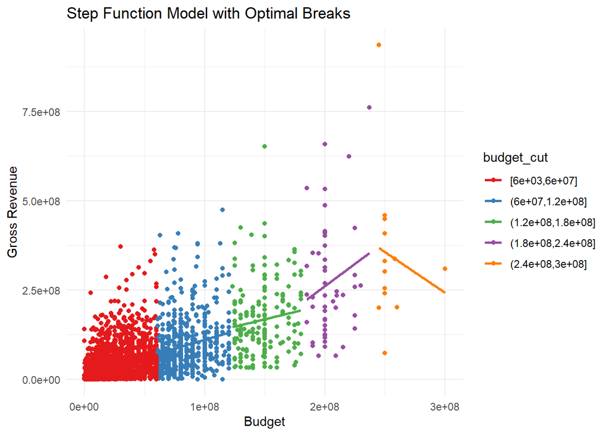

```r
# Plot the model with separate lines for each group
ggplot(movies_clean, aes(x = budget, y = gross, color = budget_cut)) +
  geom_point() +
  geom_smooth(method = "lm", aes(group = budget_cut), se = FALSE) +
  labs(title = "Step Function Model with Optimal Breaks", x = "Budget", y = "Gross Revenue") +
  theme_minimal() +
  scale_color_brewer(palette = "Set1")  # Distinct colors for each segment
```

## Natural Splines

Natural splines are used to improve the fit by handling **non-linear relationships** without overfitting.  
Unlike polynomial regression, natural splines restrict the function’s behavior at the boundaries, reducing erratic fluctuations at extreme budget values.

```r
set.seed(3)  # Ensure reproducibility

# Ensure that train_data_ns is defined
if (!exists("train_data_ns")) {
  train_data_ns <- movies_clean[, c("gross", "budget"), drop = FALSE]
  train_data_ns <- subset(train_data_ns, budget > 0)  # Remove movies with a budget of 0
}

# Explicitly define columns to avoid issues
train_data_ns <- train_data_ns %>%
  dplyr::rename(gross = gross, budget = budget) %>%
  dplyr::mutate(
    gross = as.numeric(gross),
    budget = as.numeric(budget)
  )

# Debugging: Print statements to check if data exists
cat("✅ Does train_data_ns exist? ", exists("train_data_ns"), "\n")
```

```
## ✅ Does train_data_ns exist?  TRUE
```

```r
cat("✅ Structure of train_data_ns:\n")
```

```
## ✅ Structure of train_data_ns:
```

```r
print(str(train_data_ns))
```

```
## 'data.frame':    4575 obs. of  2 variables:
##  $ gross : num  5.23e+07 7.01e+07 1.80e+08 8.52e+07 1.86e+07 ...
##  $ budget: num  8000000 6000000 15000000 18500000 9000000 6000000 25000000 6000000 9000000 15000000 ...
## NULL
```

```r
cat("✅ First rows of train_data_ns:\n")
```

```
## ✅ First rows of train_data_ns:
```

```r
print(head(train_data_ns))
```

```
##       gross   budget
## 1  52287414  8000000
## 2  70136369  6000000
## 3 179800601 15000000
## 4  85160248 18500000
## 5  18564613  9000000
## 6 138530565  6000000
```

```r
# Check if the columns are numeric
cat("✅ Column classes: ", sapply(train_data_ns, class), "\n")
```

```
## ✅ Column classes:  numeric numeric
```

```r
# Verify if there are NA values
cat("✅ Are there any NA values in gross? ", any(is.na(train_data_ns$gross)), "\n")
```

```
## ✅ Are there any NA values in gross?  FALSE
```

```r
cat("✅ Are there any NA values in budget? ", any(is.na(train_data_ns$budget)), "\n")
```

```
## ✅ Are there any NA values in budget?  FALSE
```

```r
# Define the degrees of freedom to be tested
df_range <- 3:10

# Perform cross-validation for each degree of freedom
ns_cv_results <- lapply(df_range, function(df) {
  cat("\n🔍 Testing natural spline with df =", df, "\n")  # Debugging

  # Dynamically create the formula
  formula_ns <- as.formula(paste("gross ~ ns(budget, df =", df, ")"))
  cat("📝 Formula used in the model:", format(formula_ns), "\n")  # Debug: Print the constructed formula

  # Train the model
  model <- train(
    formula_ns,
    data = train_data_ns,
    method = "lm",
    trControl = trainControl(method = "cv", number = 10, savePredictions = "final")
  )

  # Retrieve the minimum RMSE
  if (!is.null(model$results)) {
    rmse_value <- min(model$results$RMSE, na.rm = TRUE)
  } else {
    rmse_value <- NA  # If `model$results` is NULL, assign NA
  }

  list(Model = model, RMSE = rmse_value)
})
```

```
##
## 🔍 Testing natural spline with df = 3
## 📝 Formula used in the model: gross ~ ns(budget, df = 3)
##
## 🔍 Testing natural spline with df = 4
## 📝 Formula used in the model: gross ~ ns(budget, df = 4)
##
## 🔍 Testing natural spline with df = 5
## 📝 Formula used in the model: gross ~ ns(budget, df = 5)
##
## 🔍 Testing natural spline with df = 6
## 📝 Formula used in the model: gross ~ ns(budget, df = 6)
##
## 🔍 Testing natural spline with df = 7
## 📝 Formula used in the model: gross ~ ns(budget, df = 7)
##
## 🔍 Testing natural spline with df = 8
## 📝 Formula used in the model: gross ~ ns(budget, df = 8)
##
## 🔍 Testing natural spline with df = 9
## 📝 Formula used in the model: gross ~ ns(budget, df = 9)
##
## 🔍 Testing natural spline with df = 10
## 📝 Formula used in the model: gross ~ ns(budget, df = 10)
```

```r
# Identify the best degree of freedom with the lowest RMSE
best_df <- df_range[which.min(sapply(ns_cv_results, function(x) x$RMSE))]

# Final refit with the best df
final_ns_model <- lm(formula = as.formula(paste("gross ~ ns(budget,", best_df, ")")), data = train_data_ns)

# Print the summary of the final model
summary(final_ns_model)
```

```
##
## Call:
## lm(formula = as.formula(paste("gross ~ ns(budget,", best_df,
##     ")")), data = train_data_ns)
##
## Residuals:
##        Min         1Q     Median         3Q        Max
## -257674392  -21839955   -7951408   10656178  614175491
##
## Coefficients:
##                 Estimate Std. Error t value Pr(>|t|)
## (Intercept)      4154241    2118590   1.961     0.05 *
## ns(budget, 3)1  90500972    5143184  17.596   <2e-16 ***
## ns(budget, 3)2 283425391    6774346  41.838   <2e-16 ***
## ns(budget, 3)3 399035478   11235763  35.515   <2e-16 ***
## ---
## Signif. codes:  0 '***' 0.001 '**' 0.01 '*' 0.05 '.' 0.1 ' ' 1
##
## Residual standard error: 48670000 on 4571 degrees of freedom
## Multiple R-squared:  0.4653, Adjusted R-squared:  0.465
## F-statistic:  1326 on 3 and 4571 DF,  p-value: < 2.2e-16
```

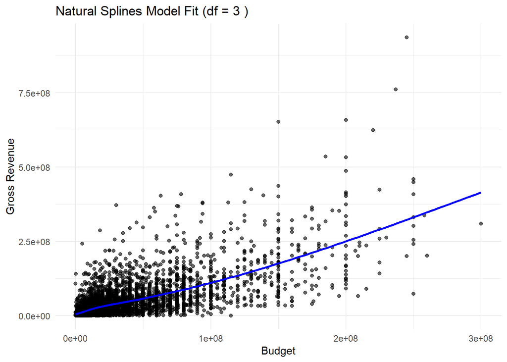

```r
# 🔍 **Visualization**
ggplot(train_data_ns, aes(x = budget, y = gross)) +
  geom_point(alpha = 0.6) +  # Scatter plot of data points
  geom_smooth(method = "lm",
              formula = as.formula(paste("y ~ ns(x,", best_df, ")")),
              se = FALSE,
              color = "blue") +  # Fitting the natural spline model
  labs(title = paste("Natural Splines Model Fit (df =", best_df, ")"),
       x = "Budget",
       y = "Gross Revenue") +
  theme_minimal()
```

## Smoothing Splines

Smoothing splines are chosen for their ability to provide a flexible fit while controlling for overfitting,  
making them reliable and preventing the model from memorizing the specific dataset.

```r
library(mgcv)  # Load package for GAM and smoothing splines

# Fit a smoothing spline model
ss_ln <- gam(gross ~ s(budget), data = movies_clean)

# Display summary of the model
summary(ss_ln)
```

```
##
## Family: gaussian
## Link function: identity
##
## Formula:
## gross ~ s(budget)
##
## Parametric coefficients:
##             Estimate Std. Error t value Pr(>|t|)
## (Intercept) 46682003     718246   64.99   <2e-16 ***
## ---
## Signif. codes:  0 '***' 0.001 '**' 0.01 '*' 0.05 '.' 0.1 ' ' 1
##
## Approximate significance of smooth terms:
##             edf Ref.df   F p-value
## s(budget) 8.416  8.891 451  <2e-16 ***
## ---
## Signif. codes:  0 '***' 0.001 '**' 0.01 '*' 0.05 '.' 0.1 ' ' 1
##
## R-sq.(adj) =  0.467   Deviance explained = 46.8%
## GCV = 2.365e+15  Scale est. = 2.3601e+15  n = 4575
```

```r
# Compute residuals and residual standard error for smoothing splines
residual_ss_complete <- resid(ss_ln)
residual_standard_error_ss_complete <- sqrt(sum(residual_ss_complete^2) / df.residual(ss_ln))

# Print residual standard error
cat("Residual Standard Error (Smoothing Splines):", residual_standard_error_ss_complete, "\n")
```

```
## Residual Standard Error (Smoothing Splines): 48581248
```

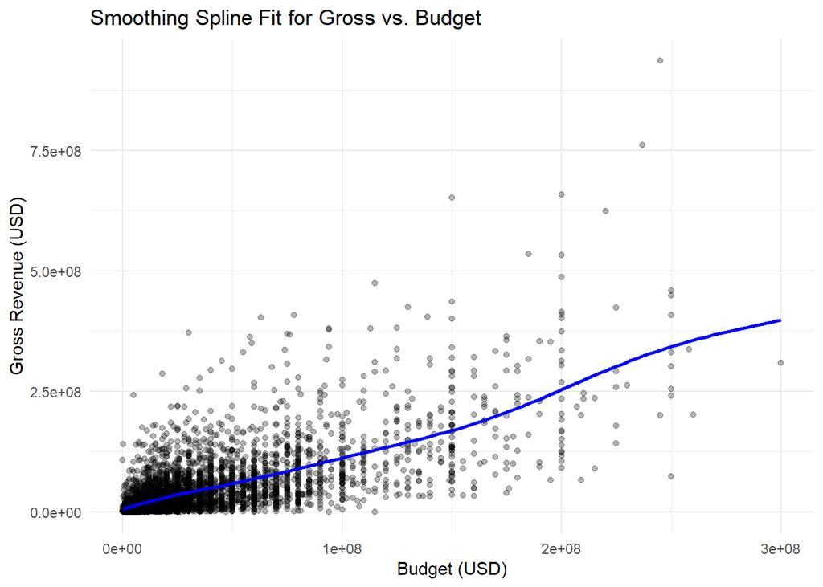

```r
# Plot the smoothing spline fit
ggplot(movies_clean, aes(x = budget, y = gross)) +
  geom_point(alpha = 0.3) +  # Slight transparency to see density of points
  geom_smooth(method = "gam", formula = y ~ s(x), se = FALSE, color = "blue") +  # Smoothing spline curve
  labs(title = "Smoothing Spline Fit for Gross vs. Budget",
       x = "Budget (USD)",
       y = "Gross Revenue (USD)") +
  theme_minimal()
```

## Local Regression

Local regression offers insight into localized trends but lacks consistency across the broader dataset.

```r
# Define a grid of possible span values
span_values <- seq(0.1, 1, by = 0.1)

# Initialize a vector to store RMSE for each span
rmse_values <- numeric(length(span_values))

# Perform cross-validation to evaluate different span values
for (i in seq_along(span_values)) {
  loess_model <- loess(gross ~ budget, data = movies_clean, span = span_values[i], control = loess.control(surface = "direct"))

  # Compute residuals and RMSE
  residuals <- movies_clean$gross - predict(loess_model)
  rmse_values[i] <- sqrt(mean(residuals^2, na.rm = TRUE))
}

# Find the best span based on the minimum RMSE
best_span_index <- which.min(rmse_values)
best_span <- span_values[best_span_index]

# Fit the best local regression model using the optimal span
best_loess_model <- loess(gross ~ budget, data = movies_clean, span = best_span, control = loess.control(surface = "direct"))

# Display summary of the best model
summary(best_loess_model)
```

```
## Call:
## loess(formula = gross ~ budget, data = movies_clean, span = best_span,
##     control = loess.control(surface = "direct"))
##
## Number of Observations: 4575
## Equivalent Number of Parameters: 33.03
## Residual Standard Error: 48730000
## Trace of smoother matrix: 36.52  (exact)
##
## Control settings:
##   span     :  0.1
##   degree   :  2
##   family   :  gaussian
##   surface  :  direct
##   normalize:  TRUE
##  parametric:  FALSE
## drop.square:  FALSE
```

```r
# Generate predictions from the best LOESS model
predictions_loess <- predict(best_loess_model, newdata = movies_clean)

# Compute residuals
residuals_loess <- movies_clean$gross - predictions_loess

# Compute R-squared
r_squared_loess <- 1 - (sum(residuals_loess^2) / sum((movies_clean$gross - mean(movies_clean$gross))^2))

# Number of predictors in the LOESS model (excluding intercept)
requested_loess <- 1  # LOESS has one main predictor (budget)

# Compute Adjusted R-squared
adj_r_squared_loess <- 1 - ((1 - r_squared_loess) * (nrow(movies_clean) - 1) / (nrow(movies_clean) - requested_loess - 1))

# Print Adjusted R-squared
cat("Adjusted R-Squared (Local Regression):", adj_r_squared_loess, "\n")
```

```
## Adjusted R-Squared (Local Regression): 0.4681402
```

```r
# Compute RMSE for the LOESS model
rmse_loess <- sqrt(mean(residuals_loess^2, na.rm = TRUE))

# Print RMSE
cat("RMSE (Local Regression):", rmse_loess, "\n")
```

```
## RMSE (Local Regression): 48514982
```

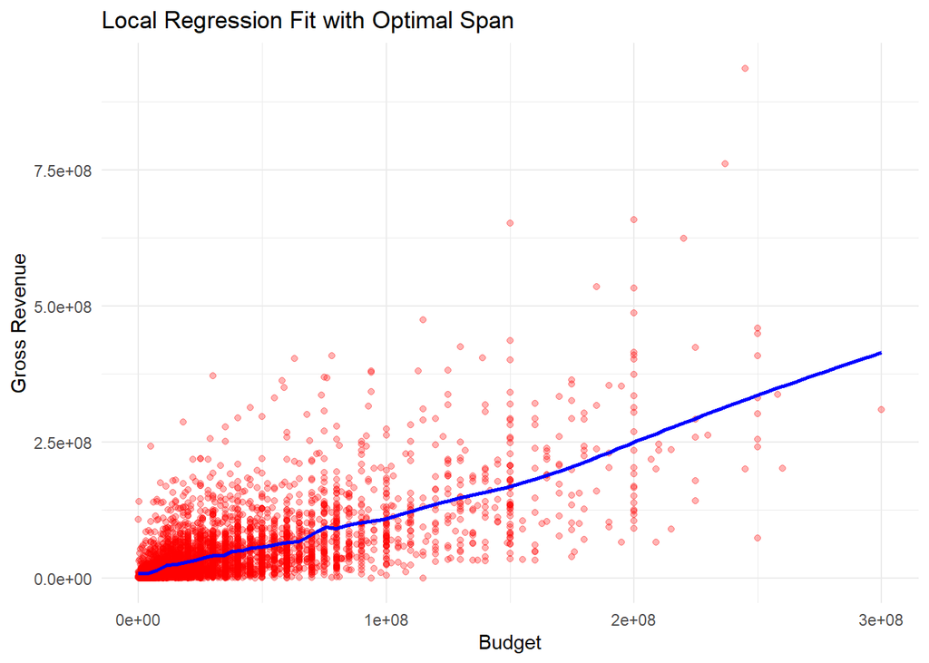

```r
# Plot the LOESS regression with the best span
ggplot(movies_clean, aes(x = budget, y = gross)) +
  geom_point(alpha = 0.3, color = "red") +  # Slight transparency to see density
  geom_smooth(method = "loess", span = best_span, se = FALSE, color = "blue") +  # LOESS curve with best span
  labs(title = "Local Regression Fit with Optimal Span",
       x = "Budget",
       y = "Gross Revenue") +
  theme_minimal()
```

## Model Selection Summary

```r
# Function to compute RMSE and R-squared
calculate_metrics <- function(actual, predicted) {
  residuals <- actual - predicted

  # Compute RMSE
  rmse_value <- sqrt(mean(residuals^2, na.rm = TRUE))

  # Compute R-squared
  r_squared_value <- 1 - (sum(residuals^2) / sum((actual - mean(actual))^2))

  return(list(RMSE = rmse_value, R_squared = r_squared_value))
}
# Define the models and obtain predictions
models_list <- list(
  lm = simple_lm,
  poly = final_poly_model,
  step = final_step_model,
  ns = final_ns_model,
  loess = best_loess_model
)

predictions_list <- list(
  lm = predict(simple_lm, newdata = movies_clean),
  poly = predict(final_poly_model, newdata = movies_clean),
  step = predict(final_step_model, newdata = movies_clean),
  ns = predict(final_ns_model, newdata = movies_clean),
  loess = predict(best_loess_model, newdata = movies_clean)
)
# Initialize a data frame to store model selection results
model_comparison <- data.frame(
  Model = names(models_list),
  RMSE = NA,
  R_squared = NA
)

# Compute RMSE and R-squared for each model
for (i in seq_along(models_list)) {
  metrics <- calculate_metrics(movies_clean$gross, predictions_list[[i]])
  model_comparison$RMSE[i] <- metrics$RMSE
  model_comparison$R_squared[i] <- metrics$R_squared
}

# Display the results
print(model_comparison)
```

```
##   Model     RMSE R_squared
## 1    lm 48909044 0.4595832
## 2  poly 48705459 0.4640729
## 3  step 51065804 0.4108704
## 4    ns 48648193 0.4653324
## 5 loess 48514982 0.4682565
```

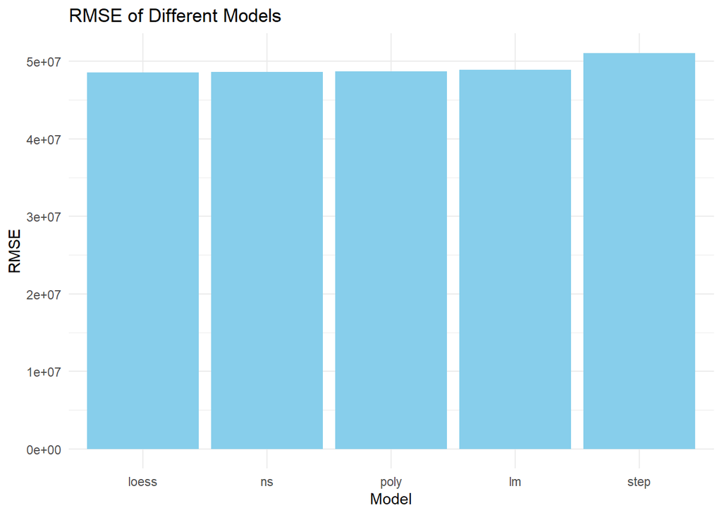

```r
# RMSE of Different Models
ggplot(model_comparison, aes(x = reorder(Model, RMSE), y = RMSE)) +
  geom_bar(stat = "identity", fill = "skyblue") +
  labs(title = "RMSE of Different Models",
       x = "Model",
       y = "RMSE") +
  theme_minimal()
```

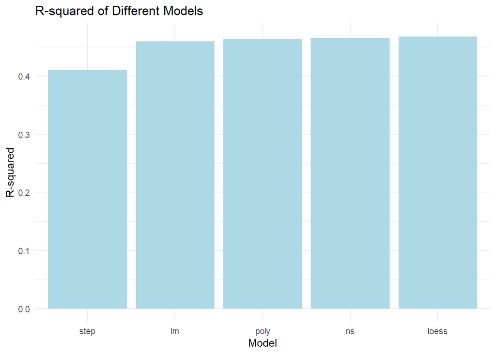

```r
# R-squared of Different Models
ggplot(model_comparison, aes(x = reorder(Model, R_squared), y = R_squared)) +
  geom_bar(stat = "identity", fill = "lightblue") +
  labs(title = "R-squared of Different Models",
       x = "Model",
       y = "R-squared") +
  theme_minimal()
```

## Conclusion

Based on the results I have plotted and reported, the Local Regression (LOESS) model is determined to be the best for explaining the relationship between movie budgets and gross revenue.  
This conclusion is drawn because the LOESS model had the lowest RMSE and the highest R-squared, indicating its superior performance in capturing the underlying patterns in the data.

## Analysis for PG-13 Rated Movies

In this section, we apply the same regression methods to a subset of movies rated **PG-13** to observe how model performance varies within this specific classification.

### Filtering PG-13 Rated Movies

Before proceeding with PG-13 based analysis, we first filter the `movies_clean` dataset to include only those movies that have a **PG-13** rating.

```r
movies_PG13 <- movies_clean %>% filter(rating == "PG-13")
```

## Simple Linear Regression (PG-13)

First, we apply **simple linear regression** to examine the direct relationship between **budget** and **gross revenue** for PG-13 rated movies.

```r
# Create a simple linear regression model for PG-13 movies
simple_lm_PG13 <- lm(gross ~ budget, data = movies_PG13)

# Display summary of the model
summary(simple_lm_PG13)
```

```
##
## Call:
## lm(formula = gross ~ budget, data = movies_PG13)
##
## Residuals:
##        Min         1Q     Median         3Q        Max
## -227008612  -26479287   -9063822   16404018  642471337
##
## Coefficients:
##              Estimate Std. Error t value Pr(>|t|)
## (Intercept) 5.296e+06  2.206e+06   2.401   0.0165 *
## budget      1.179e+00  3.205e-02  36.796   <2e-16 ***
## ---
## Signif. codes:  0 '***' 0.001 '**' 0.01 '*' 0.05 '.' 0.1 ' ' 1
##
## Residual standard error: 61040000 on 1558 degrees of freedom
## Multiple R-squared:  0.465,  Adjusted R-squared:  0.4646
## F-statistic:  1354 on 1 and 1558 DF,  p-value: < 2.2e-16
```

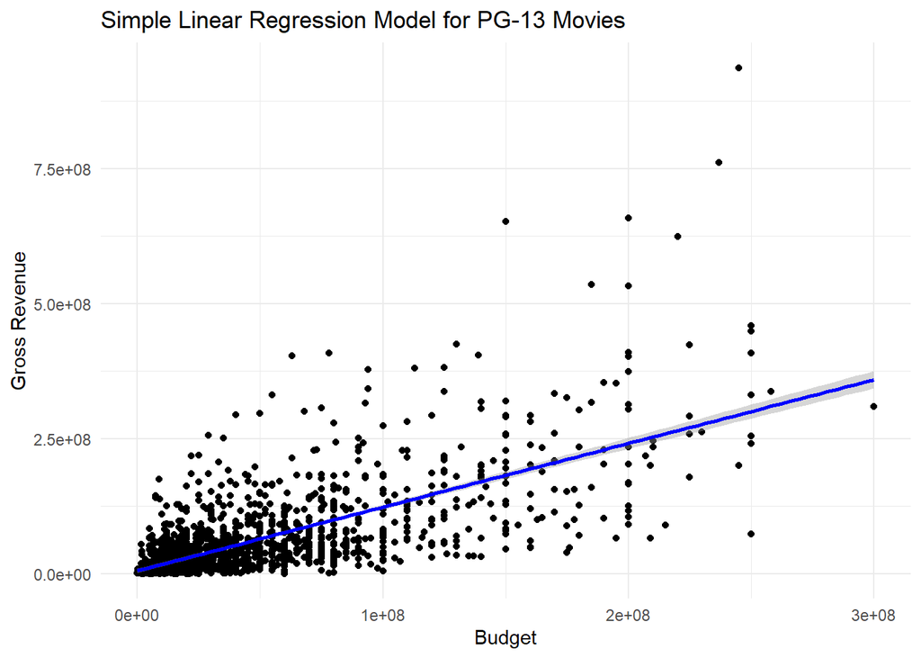

```r
# Plot the regression model for PG-13 movies
ggplot(movies_PG13, aes(x = budget, y = gross)) +
  geom_point() +  # Adds scatter plot points
  geom_smooth(method = "lm", formula = y ~ x, color = "blue") +  # Adds the regression line
  labs(title = "Simple Linear Regression Model for PG-13 Movies",
       x = "Budget",
       y = "Gross Revenue") +
  theme_minimal()
```

## Polynomial Regression (PG-13)

Next, we employ **polynomial regression**.

```r
set.seed(1)  # Ensure reproducibility

# Ensure that train_data_pg13 is defined
if (!exists("train_data_pg13")) {
  train_data_pg13 <- movies_PG13[, c("gross", "budget"), drop = FALSE]
  train_data_pg13 <- subset(train_data_pg13, budget > 0)  # Remove movies with a budget of 0
}

# Explicitly define columns to avoid issues
train_data_pg13 <- train_data_pg13 %>%
  dplyr::rename(gross = gross, budget = budget) %>%
  dplyr::mutate(
    gross = as.numeric(gross),
    budget = as.numeric(budget)
  )

# Debugging: Print statements to check if data exists
cat("✅ Does train_data_pg13 exist? ", exists("train_data_pg13"), "\n")
```

```
## ✅ Does train_data_pg13 exist?  TRUE
```

```r
cat("✅ Structure of train_data_pg13:\n")
```

```
## ✅ Structure of train_data_pg13:
```

```r
print(str(train_data_pg13))
```

```
## 'data.frame':    1560 obs. of  2 variables:
##  $ gross : num  7.01e+07 4.05e+07 1.75e+08 8.20e+06 1.11e+07 ...
##  $ budget: num  6.0e+06 9.0e+06 8.8e+06 6.0e+06 2.5e+07 2.5e+07 2.7e+06 2.0e+06 1.1e+07 2.5e+07 ...
## NULL
```

```r
cat("✅ First rows of train_data_pg13:\n")
```

```
## ✅ First rows of train_data_pg13:
```

```r
print(head(train_data_pg13))
```

```
##       gross  budget
## 1  70136369 6.0e+06
## 2  40471663 9.0e+06
## 3 174635000 8.8e+06
## 4   8200000 6.0e+06
## 5  11100000 2.5e+07
## 6  38747385 2.5e+07
```

```r
# Check if the columns are numeric
cat("✅ Column classes: ", sapply(train_data_pg13, class), "\n")
```

```
## ✅ Column classes:  numeric numeric
```

```r
# Verify if there are NA values
cat("✅ Are there any NA values in gross? ", any(is.na(train_data_pg13$gross)), "\n")
```

```
## ✅ Are there any NA values in gross?  FALSE
```

```r
cat("✅ Are there any NA values in budget? ", any(is.na(train_data_pg13$budget)), "\n")
```

```
## ✅ Are there any NA values in budget?  FALSE
```

```r
# Define the polynomial degrees to be tested
degrees_pg13 <- 1:4

# Perform cross-validation for each polynomial degree
cv_results_pg13 <- lapply(degrees_pg13, function(degree) {
  cat("\n🔍 Testing polynomial degree:", degree, "\n")  # Debugging

  # Manually construct polynomial columns
  train_data_fixed_pg13 <- train_data_pg13
  for (d in 2:degree) {
    train_data_fixed_pg13[[paste0("budget_poly_", d)]] <- train_data_fixed_pg13$budget^d
  }

  # Dynamically construct the formula
  formula_poly_pg13 <- as.formula(
    paste("gross ~", paste(c("budget", paste0("budget_poly_", 2:degree)), collapse = " + "))
  )

  cat("📝 Formula used in the model:", format(formula_poly_pg13), "\n")  # Debug: Print the constructed formula

  # Train the model
  model_pg13 <- train(
    formula_poly_pg13,
    data = train_data_fixed_pg13,
    method = "lm",
    trControl = trainControl(method = "cv", number = 10, savePredictions = "final")
  )

  # Retrieve the minimum RMSE
  if (!is.null(model_pg13$results)) {
    rmse_value_pg13 <- min(model_pg13$results$RMSE, na.rm = TRUE)
  } else {
    rmse_value_pg13 <- NA  # If `model_pg13$results` is NULL, assign NA
  }

  list(Model = model_pg13, RMSE = rmse_value_pg13)
})
```

```
##
## 🔍 Testing polynomial degree: 1
## 📝 Formula used in the model: gross ~ budget + budget_poly_2 + budget_poly_1
```

```
##
## 🔍 Testing polynomial degree: 2
## 📝 Formula used in the model: gross ~ budget + budget_poly_2
##
## 🔍 Testing polynomial degree: 3
## 📝 Formula used in the model: gross ~ budget + budget_poly_2 + budget_poly_3
##
## 🔍 Testing polynomial degree: 4
## 📝 Formula used in the model: gross ~ budget + budget_poly_2 + budget_poly_3 + budget_poly_4
```

```r
# Identify the polynomial degree with the lowest RMSE
best_degree_pg13 <- degrees_pg13[which.min(sapply(cv_results_pg13, function(x) x$RMSE))]

# Final refit with the best degree
final_poly_model_pg13 <- lm(formula = gross ~ poly(budget, best_degree_pg13, raw = TRUE), data = train_data_pg13)

# Print the summary of the final model
summary(final_poly_model_pg13)
```

```
##
## Call:
## lm(formula = gross ~ poly(budget, best_degree_pg13, raw = TRUE),
##     data = train_data_pg13)
##
## Residuals:
##        Min         1Q     Median         3Q        Max
## -278521839  -26414018  -11331525   15315934  595721418
##
## Coefficients:
##                                              Estimate Std. Error t value
## (Intercept)                                 1.327e+07  3.850e+06   3.446
## poly(budget, best_degree_pg13, raw = TRUE)1 9.003e-01  1.837e-01   4.901
## poly(budget, best_degree_pg13, raw = TRUE)2 4.191e-10  2.051e-09   0.204
## poly(budget, best_degree_pg13, raw = TRUE)3 5.573e-18  6.060e-18   0.920
##                                             Pr(>|t|)
## (Intercept)                                 0.000584 ***
## poly(budget, best_degree_pg13, raw = TRUE)1 1.05e-06 ***
## poly(budget, best_degree_pg13, raw = TRUE)2 0.838135
## poly(budget, best_degree_pg13, raw = TRUE)3 0.357966
## ---
## Signif. codes:  0 '***' 0.001 '**' 0.01 '*' 0.05 '.' 0.1 ' ' 1
##
## Residual standard error: 60580000 on 1556 degrees of freedom
## Multiple R-squared:  0.4736, Adjusted R-squared:  0.4726
## F-statistic: 466.7 on 3 and 1556 DF,  p-value: < 2.2e-16
```

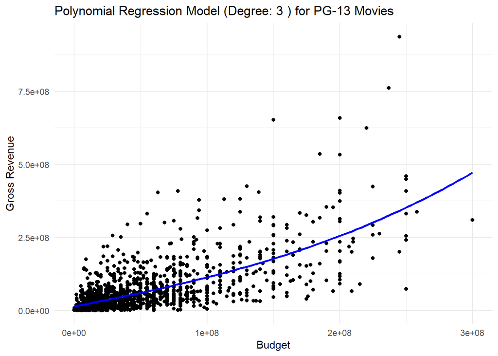

```r
# Plot the polynomial regression model for PG-13 movies
ggplot(train_data_pg13, aes(x = budget, y = gross)) +
  geom_point() +  # Scatter plot of data
  geom_smooth(method = "lm",
              formula = as.formula(paste("y ~ poly(x,", best_degree_pg13, ", raw = TRUE)")),
              se = FALSE,
              color = "blue") +  # Polynomial regression curve
  labs(title = paste("Polynomial Regression Model (Degree:", best_degree_pg13, ") for PG-13 Movies"),
       x = "Budget",
       y = "Gross Revenue") +
  theme_minimal()
```

## Step Functions (PG-13)

Now we employ **step functions**.

```r
set.seed(1)  # Ensure reproducibility

# Define a list of possible break points for the step function
breaks_list_pg13 <- list(
  seq(min(movies_PG13$budget), max(movies_PG13$budget), length.out = 4),
  seq(min(movies_PG13$budget), max(movies_PG13$budget), length.out = 5),
  seq(min(movies_PG13$budget), max(movies_PG13$budget), length.out = 6),
  seq(min(movies_PG13$budget), max(movies_PG13$budget), length.out = 7)
)

# Calculate RMSE for each set of breaks using cross-validation
cv_results_pg13 <- lapply(breaks_list_pg13, function(breaks) {
  movies_PG13$budget_cut <- cut(movies_PG13$budget, breaks = breaks, include.lowest = TRUE)
  step_model_pg13 <- train(gross ~ budget_cut,
                           data = movies_PG13,
                           method = "lm",
                           trControl = trainControl(method = "cv", number = 10, savePredictions = "final"))

  # Return RMSE for each break setup
  list(Model = step_model_pg13, RMSE = min(step_model_pg13$results$RMSE))
})

# Select the index of the breaks with the lowest RMSE
best_break_index_pg13 <- which.min(sapply(cv_results_pg13, function(x) x$RMSE))
best_breaks_pg13 <- breaks_list_pg13[[best_break_index_pg13]]

# Assign the optimal budget cut in the PG-13 dataset
movies_PG13$budget_cut <- cut(movies_PG13$budget, breaks = best_breaks_pg13, include.lowest = TRUE)

# Fit the final step function model using the optimal breaks
final_step_model_pg13 <- lm(gross ~ budget_cut, data = movies_PG13)

# Display summary of the final model
summary(final_step_model_pg13)
```

```
##
## Call:
## lm(formula = gross ~ budget_cut, data = movies_PG13)
##
## Residuals:
##        Min         1Q     Median         3Q        Max
## -290335203  -31159786  -13657372   19158602  573248922
##
## Coefficients:
##                              Estimate Std. Error t value Pr(>|t|)
## (Intercept)                  37209852    1812925   20.52   <2e-16 ***
## budget_cut(6e+07,1.2e+08]    60546536    4304485   14.07   <2e-16 ***
## budget_cut(1.2e+08,1.8e+08] 131573104    6536595   20.13   <2e-16 ***
## budget_cut(1.8e+08,2.4e+08] 242958556   10328815   23.52   <2e-16 ***
## budget_cut(2.4e+08,3e+08]   326203451   18737104   17.41   <2e-16 ***
## ---
## Signif. codes:  0 '***' 0.001 '**' 0.01 '*' 0.05 '.' 0.1 ' ' 1
##
## Residual standard error: 61850000 on 1555 degrees of freedom
## Multiple R-squared:  0.4517, Adjusted R-squared:  0.4503
## F-statistic: 320.2 on 4 and 1555 DF,  p-value: < 2.2e-16
```

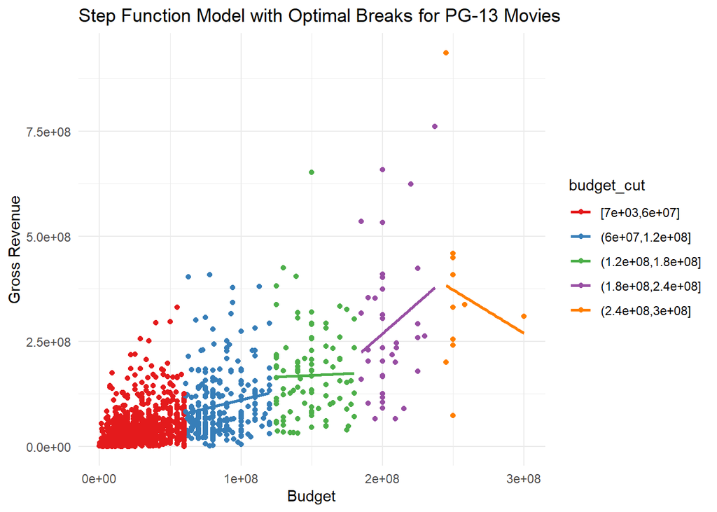

```r
# Plot the model with stepwise lines for each group
ggplot(movies_PG13, aes(x = budget, y = gross, color = budget_cut)) +
  geom_point() +  # Scatter plot of data points
  geom_smooth(method = "lm", aes(group = budget_cut), se = FALSE) +  # Stepwise regression lines
  labs(title = "Step Function Model with Optimal Breaks for PG-13 Movies",
       x = "Budget",
       y = "Gross Revenue") +
  theme_minimal() +
  scale_color_brewer(palette = "Set1")  # Distinct colors for each segment
```

## Natural Splines (PG-13)

Now we employ **natural splines**.

```r
set.seed(3)  # Ensure reproducibility

# Ensure that train_data_ns_pg13 is defined
if (!exists("train_data_ns_pg13")) {
  train_data_ns_pg13 <- movies_PG13[, c("gross", "budget"), drop = FALSE]
  train_data_ns_pg13 <- subset(train_data_ns_pg13, budget > 0)  # Remove movies with a budget of 0
}

# Explicitly define columns to avoid issues
train_data_ns_pg13 <- train_data_ns_pg13 %>%
  dplyr::rename(gross = gross, budget = budget) %>%
  dplyr::mutate(
    gross = as.numeric(gross),
    budget = as.numeric(budget)
  )

# Debugging: Print statements to check if data exists
cat("✅ Does train_data_ns_pg13 exist? ", exists("train_data_ns_pg13"), "\n")
```

```
## ✅ Does train_data_ns_pg13 exist?  TRUE
```

```r
cat("✅ Structure of train_data_ns_pg13:\n")
```

```
## ✅ Structure of train_data_ns_pg13:
```

```r
print(str(train_data_ns_pg13))
```

```
## 'data.frame':    1560 obs. of  2 variables:
##  $ gross : num  7.01e+07 4.05e+07 1.75e+08 8.20e+06 1.11e+07 ...
##  $ budget: num  6.0e+06 9.0e+06 8.8e+06 6.0e+06 2.5e+07 2.5e+07 2.7e+06 2.0e+06 1.1e+07 2.5e+07 ...
## NULL
```

```r
cat("✅ First rows of train_data_ns_pg13:\n")
```

```
## ✅ First rows of train_data_ns_pg13:
```

```r
print(head(train_data_ns_pg13))
```

```
##       gross  budget
## 1  70136369 6.0e+06
## 2  40471663 9.0e+06
## 3 174635000 8.8e+06
## 4   8200000 6.0e+06
## 5  11100000 2.5e+07
## 6  38747385 2.5e+07
```

```r
# Check if the columns are numeric
cat("✅ Column classes: ", sapply(train_data_ns_pg13, class), "\n")
```

```
## ✅ Column classes:  numeric numeric
```

```r
# Verify if there are NA values
cat("✅ Are there any NA values in gross? ", any(is.na(train_data_ns_pg13$gross)), "\n")
```

```
## ✅ Are there any NA values in gross?  FALSE
```

```r
cat("✅ Are there any NA values in budget? ", any(is.na(train_data_ns_pg13$budget)), "\n")
```

```
## ✅ Are there any NA values in budget?  FALSE
```

```r
# Define the degrees of freedom to be tested
df_range_pg13 <- 3:10

# Perform cross-validation for each degree of freedom
ns_cv_results_pg13 <- lapply(df_range_pg13, function(df) {
  cat("\n🔍 Testing natural spline with df =", df, "\n")  # Debugging

  # Dynamically create the formula
  formula_ns_pg13 <- as.formula(paste("gross ~ ns(budget, df =", df, ")"))
  cat("📝 Formula used in the model:", format(formula_ns_pg13), "\n")  # Debug: Print the constructed formula

  # Train the model
  model_pg13 <- train(
    formula_ns_pg13,
    data = train_data_ns_pg13,
    method = "lm",
    trControl = trainControl(method = "cv", number = 10, savePredictions = "final")
  )

  # Retrieve the minimum RMSE
  if (!is.null(model_pg13$results)) {
    rmse_value_pg13 <- min(model_pg13$results$RMSE, na.rm = TRUE)
  } else {
    rmse_value_pg13 <- NA  # If `model_pg13$results` is NULL, assign NA
  }

  list(Model = model_pg13, RMSE = rmse_value_pg13)
})
```

```
##
## 🔍 Testing natural spline with df = 3
## 📝 Formula used in the model: gross ~ ns(budget, df = 3)
##
## 🔍 Testing natural spline with df = 4
## 📝 Formula used in the model: gross ~ ns(budget, df = 4)
##
## 🔍 Testing natural spline with df = 5
## 📝 Formula used in the model: gross ~ ns(budget, df = 5)
##
## 🔍 Testing natural spline with df = 6
## 📝 Formula used in the model: gross ~ ns(budget, df = 6)
##
## 🔍 Testing natural spline with df = 7
## 📝 Formula used in the model: gross ~ ns(budget, df = 7)
##
## 🔍 Testing natural spline with df = 8
## 📝 Formula used in the model: gross ~ ns(budget, df = 8)
##
## 🔍 Testing natural spline with df = 9
## 📝 Formula used in the model: gross ~ ns(budget, df = 9)
##
## 🔍 Testing natural spline with df = 10
## 📝 Formula used in the model: gross ~ ns(budget, df = 10)
```

```r
# Identify the best degree of freedom with the lowest RMSE
best_df_pg13 <- df_range_pg13[which.min(sapply(ns_cv_results_pg13, function(x) x$RMSE))]

# Final refit with the best df
final_ns_model_pg13 <- lm(formula = as.formula(paste("gross ~ ns(budget,", best_df_pg13, ")")), data = train_data_ns_pg13)

# Print the summary of the final model
summary(final_ns_model_pg13)
```

```
##
## Call:
## lm(formula = as.formula(paste("gross ~ ns(budget,", best_df_pg13,
##     ")")), data = train_data_ns_pg13)
##
## Residuals:
##        Min         1Q     Median         3Q        Max
## -277895776  -26822975  -11096444   14608619  595284325
##
## Coefficients:
##                 Estimate Std. Error t value Pr(>|t|)
## (Intercept)      7536014    8579412   0.878  0.37987
## ns(budget, 5)1  26410164    8887880   2.971  0.00301 **
## ns(budget, 5)2  54232959   10549933   5.141 3.09e-07 ***
## ns(budget, 5)3 112994749   12577673   8.984  < 2e-16 ***
## ns(budget, 5)4 311886856   21511057  14.499  < 2e-16 ***
## ns(budget, 5)5 431374574   20994145  20.547  < 2e-16 ***
## ---
## Signif. codes:  0 '***' 0.001 '**' 0.01 '*' 0.05 '.' 0.1 ' ' 1
##
## Residual standard error: 60590000 on 1554 degrees of freedom
## Multiple R-squared:  0.4742, Adjusted R-squared:  0.4725
## F-statistic: 280.3 on 5 and 1554 DF,  p-value: < 2.2e-16
```

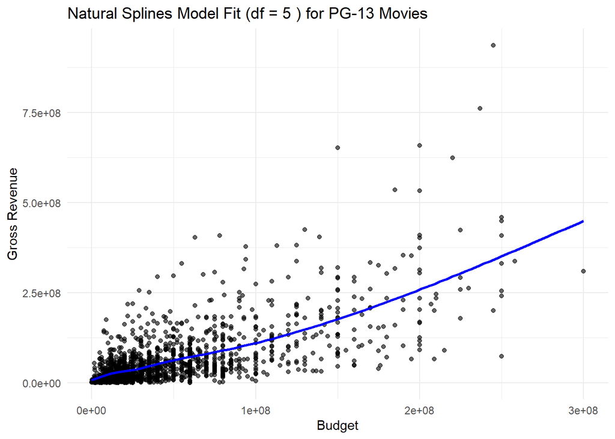

```r
# 🔍 **Visualization**
ggplot(train_data_ns_pg13, aes(x = budget, y = gross)) +
  geom_point(alpha = 0.6) +  # Scatter plot of data points
  geom_smooth(method = "lm",
              formula = as.formula(paste("y ~ ns(x,", best_df_pg13, ")")),
              se = FALSE,
              color = "blue") +  # Fitting the natural spline model
  labs(title = paste("Natural Splines Model Fit (df =", best_df_pg13, ") for PG-13 Movies"),
       x = "Budget",
       y = "Gross Revenue") +
  theme_minimal()
```

## Smoothing Splines (PG-13)

Now we apply **smoothing splines**.

```r
# Fit a smoothing spline model for PG-13 movies
ss_pg13 <- gam(gross ~ s(budget), data = movies_PG13)

# Display summary of the model
summary(ss_pg13)
```

```
##
## Family: gaussian
## Link function: identity
##
## Formula:
## gross ~ s(budget)
##
## Parametric coefficients:
##             Estimate Std. Error t value Pr(>|t|)
## (Intercept) 63195414    1526756   41.39   <2e-16 ***
## ---
## Signif. codes:  0 '***' 0.001 '**' 0.01 '*' 0.05 '.' 0.1 ' ' 1
##
## Approximate significance of smooth terms:
##             edf Ref.df     F p-value
## s(budget) 7.913  8.687 164.5  <2e-16 ***
## ---
## Signif. codes:  0 '***' 0.001 '**' 0.01 '*' 0.05 '.' 0.1 ' ' 1
##
## R-sq.(adj) =  0.477   Deviance explained =   48%
## GCV = 3.6572e+15  Scale est. = 3.6363e+15  n = 1560
```

```r
# Compute residuals for the smoothing spline model
residuals_ss_pg13 <- resid(ss_pg13)

# Compute Residual Standard Error
residual_standard_error_ss_pg13 <- sqrt(sum(residuals_ss_pg13^2) / df.residual(ss_pg13))

# Print Residual Standard Error
cat("Residual Standard Error (Smoothing Splines, PG-13):", residual_standard_error_ss_pg13, "\n")
```

```
## Residual Standard Error (Smoothing Splines, PG-13): 60302013
```

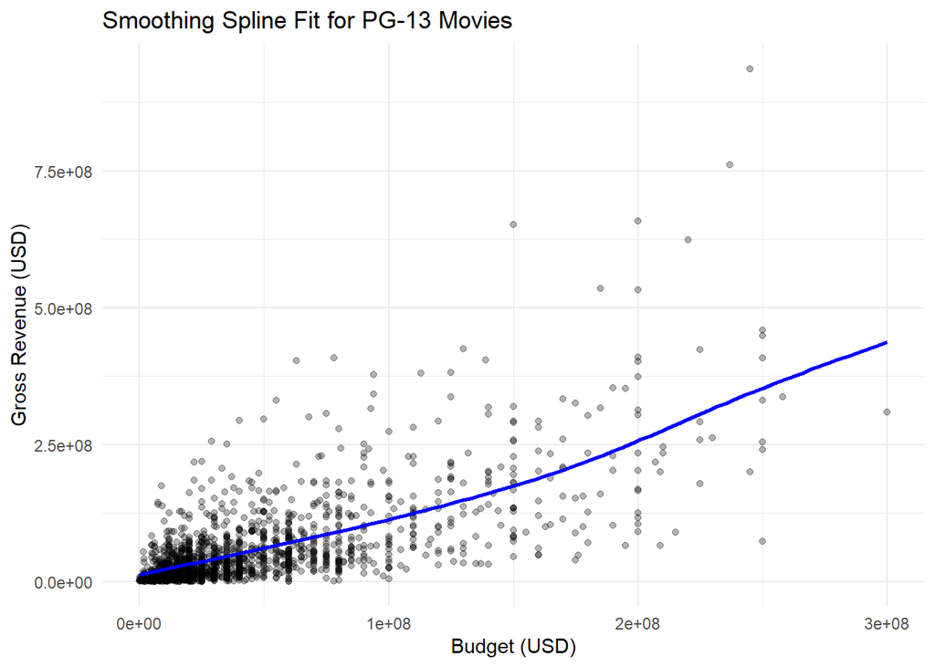

```r
# Plot the smoothing spline fit
ggplot(movies_PG13, aes(x = budget, y = gross)) +
  geom_point(alpha = 0.3) +  # Scatter plot with transparency
  geom_smooth(method = "gam", formula = y ~ s(x), se = FALSE, color = "blue") +  # Smoothing spline curve
  labs(title = "Smoothing Spline Fit for PG-13 Movies",
       x = "Budget (USD)",
       y = "Gross Revenue (USD)") +
  theme_minimal()
```

## Local Regression (PG-13)

Lastly, **local regression** is applied.

```r
library(ggplot2)

# Define a grid of possible span values
span_values_pg13 <- seq(0.1, 1, by = 0.1)

# Initialize a vector to store RMSE for each span
rmse_values_pg13 <- numeric(length(span_values_pg13))

# Perform cross-validation to evaluate different span values
for (i in seq_along(span_values_pg13)) {
  loess_model_pg13 <- loess(gross ~ budget, data = movies_PG13, span = span_values_pg13[i],
                            control = loess.control(surface = "direct"))

  # Compute residuals and RMSE
  residuals_pg13 <- movies_PG13$gross - predict(loess_model_pg13)
  rmse_values_pg13[i] <- sqrt(mean(residuals_pg13^2, na.rm = TRUE))
}

# Find the best span based on the minimum RMSE
best_span_index_pg13 <- which.min(rmse_values_pg13)
best_span_pg13 <- span_values_pg13[best_span_index_pg13]

# Fit the best local regression model using the optimal span
best_loess_model_pg13 <- loess(gross ~ budget, data = movies_PG13, span = best_span_pg13,
                              control = loess.control(surface = "direct"))

# Display summary of the best model
summary(best_loess_model_pg13)
```

```
## Call:
## loess(formula = gross ~ budget, data = movies_PG13, span = best_span_pg13,
##     control = loess.control(surface = "direct"))
##
## Number of Observations: 1560
## Equivalent Number of Parameters: 31.43
## Residual Standard Error: 60520000
## Trace of smoother matrix: 34.75  (exact)
##
## Control settings:
##   span     :  0.1
##   degree   :  2
##   family   :  gaussian
##   surface  :  direct
##   normalize:  TRUE
##  parametric:  FALSE
## drop.square:  FALSE
```

```r
# Generate predictions from the best LOESS model
predictions_loess_pg13 <- predict(best_loess_model_pg13, newdata = movies_PG13)

# Compute residuals
residuals_loess_pg13 <- movies_PG13$gross - predictions_loess_pg13

# Compute R-squared
r_squared_loess_pg13 <- 1 - (sum(residuals_loess_pg13^2) / sum((movies_PG13$gross - mean(movies_PG13$gross))^2))

# Number of predictors in the LOESS model (excluding intercept)
requested_loess_pg13 <- 1  # LOESS has one main predictor (budget)

# Compute Adjusted R-squared
adj_r_squared_loess_pg13 <- 1 - ((1 - r_squared_loess_pg13) * (nrow(movies_PG13) - 1) / (nrow(movies_PG13) - requested_loess_pg13 - 1))

# Print Adjusted R-squared
cat("Adjusted R-Squared (Local Regression, PG-13):", adj_r_squared_loess_pg13, "\n")
```

```
## Adjusted R-Squared (Local Regression, PG-13): 0.4859336
```

```r
# Compute RMSE for the LOESS model
rmse_loess_pg13 <- sqrt(mean(residuals_loess_pg13^2, na.rm = TRUE))

# Print RMSE
cat("RMSE (Local Regression, PG-13):", rmse_loess_pg13, "\n")
```

```
## RMSE (Local Regression, PG-13): 59774109
```

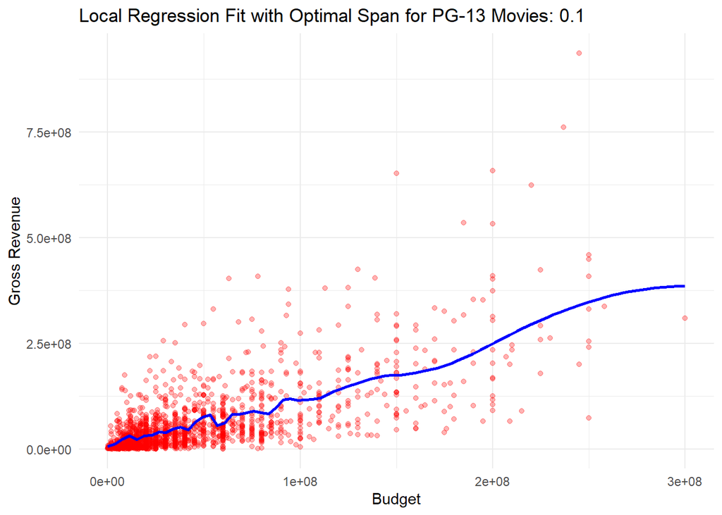

```r
# Plot the LOESS regression with the best span
ggplot(movies_PG13, aes(x = budget, y = gross)) +
  geom_point(alpha = 0.3, color = "red") +  # Slight transparency to see density
  geom_smooth(method = "loess", span = best_span_pg13, se = FALSE, color = "blue") +  # LOESS curve with best span
  labs(title = paste("Local Regression Fit with Optimal Span for PG-13 Movies:", best_span_pg13),
       x = "Budget",
       y = "Gross Revenue") +
  theme_minimal()
```

## Model Selection (PG-13)

### Functions to Calculate RMSE and R-squared

```r
# Function to compute RMSE and R-squared
calculate_rmse <- function(actual, predicted) {
  sqrt(mean((actual - predicted)^2, na.rm = TRUE))
}

calculate_r_squared <- function(actual, predicted) {
  1 - (sum((actual - predicted)^2) / sum((actual - mean(actual))^2))
}
# Define the models and obtain predictions
models_pg13 <- list(
  lm = simple_lm_PG13,
  poly = final_poly_model_pg13,
  step = final_step_model_pg13,
  ns = final_ns_model_pg13,
  loess = best_loess_model_pg13
)

predictions_pg13 <- list(
  lm = predict(simple_lm_PG13, newdata = movies_PG13),
  poly = predict(final_poly_model_pg13, newdata = movies_PG13),
  step = predict(final_step_model_pg13, newdata = movies_PG13),
  ns = predict(final_ns_model_pg13, newdata = movies_PG13),
  loess = predict(best_loess_model_pg13, newdata = movies_PG13)
)
# Initialize a data frame to store model selection results
model_comparison_pg13 <- data.frame(
  Model = names(models_pg13),
  RMSE = NA,
  R_squared = NA
)

# Compute RMSE and R-squared for each model
for (i in seq_along(models_pg13)) {
  model_comparison_pg13$RMSE[i] <- calculate_rmse(movies_PG13$gross, predictions_pg13[[i]])
  model_comparison_pg13$R_squared[i] <- calculate_r_squared(movies_PG13$gross, predictions_pg13[[i]])
}

# Display the results
print(model_comparison_pg13)
```

```
##   Model     RMSE R_squared
## 1    lm 61000494 0.4649664
## 2  poly 60504709 0.4736281
## 3  step 61753169 0.4516815
## 4    ns 60473735 0.4741669
## 5 loess 59774109 0.4862633
```

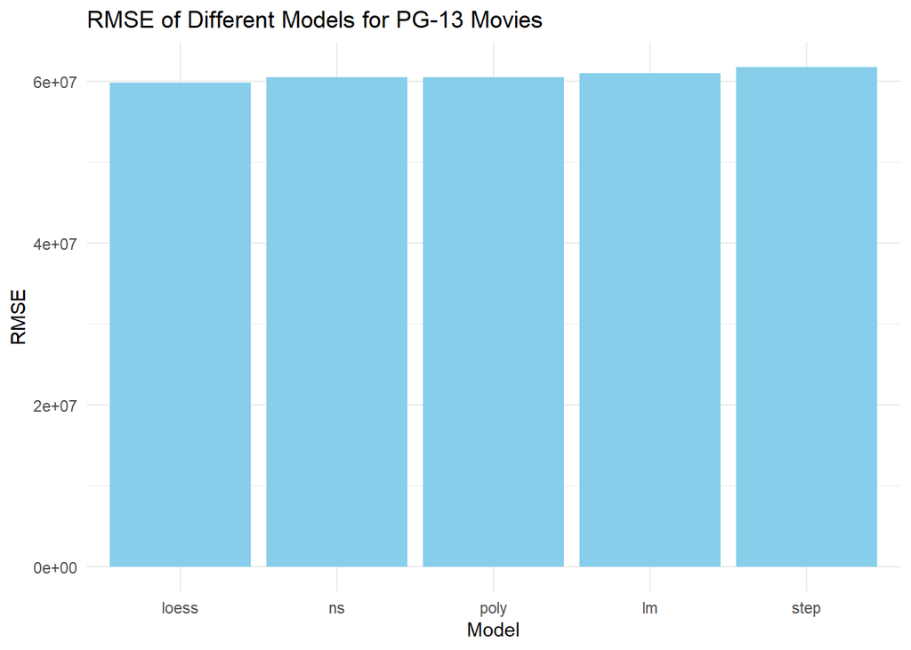

```r
# Plot RMSE of different models for PG-13 movies
ggplot(model_comparison_pg13, aes(x = reorder(Model, RMSE), y = RMSE)) +
  geom_bar(stat = "identity", fill = "skyblue") +
  labs(title = "RMSE of Different Models for PG-13 Movies",
       x = "Model",
       y = "RMSE") +
  theme_minimal()
```

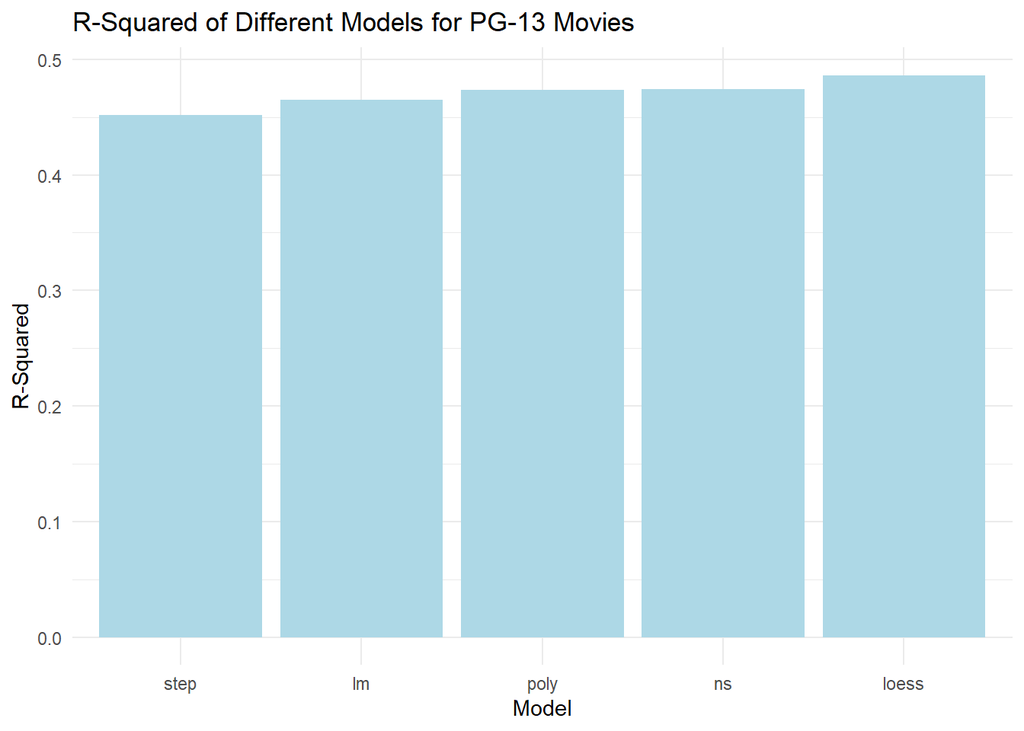

```r
# Plot R-Squared of different models for PG-13 movies
ggplot(model_comparison_pg13, aes(x = reorder(Model, R_squared), y = R_squared)) +
  geom_bar(stat = "identity", fill = "lightblue") +
  labs(title = "R-Squared of Different Models for PG-13 Movies",
       x = "Model",
       y = "R-Squared") +
  theme_minimal()
```

## Conclusion

Based on the results plotted and reported, the **Local Regression (LOESS)** model is determined to be the best for explaining the relationship between **movie budgets** and **gross revenues** in the **PG-13 subset**.

This conclusion is drawn because the **LOESS model had the lowest RMSE** and the **highest R-squared**, indicating, once again, its **superior performance** in capturing the underlying patterns in the data.